# Exam 1

## Exam 1

#### Metainformation

1. | Tag | Value |
   | --- | --- |
   | `file` | Inferential_Statistics_vufsw-mixed_design_anova-1064-en_vufsw-mixed_design_anova-1064-en |
   | `name` | vufsw-mixed design anova-1064-en |
   | `section` | inferential statistics/parametric techniques/anova/mixed design anova |
   | `type` | num |
   | `solution` | 0.1489 |
   | `tolerance` | 0.000399999999999998 |
   | `ID` | 4fc6a |
   | `Type` | interpreting out |
   | `Program` | calculator |
   | `Language` | English |
   | `Level` | statistical thinking |

#### Question

   On the basis of the output below, Field and Lawson (2003) reported the effects of giving the same children aged 7–9 years positive, negative or no information about novel animals. This variable was called ‘Infotype’ (levels of Infotype were entered in the following order: positive information, negative information, no information). The gender of the child was also examined. The outcome was the centred time taken for the children to put their hand in a box in which they believed either the positive, negative or no information animal was housed. The assumption of Sphericity is not violated.

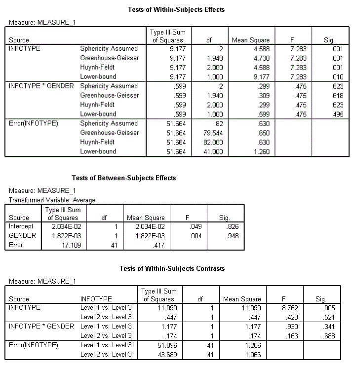

   Contrast analysis was performed on these data (levels of Infotype were entered in the following order: positive information, negative information, no information). Using the SPSS output given above, calculate the effect size (*r*) of the interaction between the contrast between positive information and no information and gender. Round your answer to **four** decimal places.

#### Solution

   You use the formula for the r of the contrasten

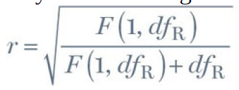

   F(1,41)=0.930 and df<sub>R</sub>=41. The outcome is 0.1489.

   Language  
   English & Nederlands

   M&T Mixed design ANOVA  
   Default value

   M&T MVA  
   Standaardwaarde